# Report_mm_chenge

Alexandru Cernat

14 July, 2021

## Some descriptives on the variables we selected to analyse

| Code | Label | Type of Variable | Wave |
| --- | --- | --- | --- |
| aidxhh | Non-residents cared for | binary | 567810 |
| caruse | Has use of a car or a van | binary | 5678910 |
| finfut | Subjective financial situation - future | ordinal | 5678910 |
| finnow | Subjective financial situation -current | ordinal | 5678910 |
| fiyrdia | Amount received in interest/dividends | continuous | 5678910 |
| howlng | Time spent on housework | continuous | 567 |
| j2has | Has a second job | binary | 5678910 |
| jbhas | Did paid work last week | binary | 5678910 |
| jbsemp | Employed (or self-employed): current job | binary | 5678910 |
| jbterm1 | Current job: permanent or temporary | binary | 5678910 |
| lkmove | Prefers to move house | binary | 567810 |
| mobuse | Has mobile phone | binary | 5678910 |
| netpuse | Frequency of using the internet | ordinal | 5678910 |
| scghqa | Ghq: concentration | ordinal | 567810 |
| scghqb | Ghq: loss of sleep | ordinal | 567810 |
| scghqc | Ghq: playing a useful role | ordinal | 567810 |
| scghqd | Ghq: capable of making decisions | ordinal | 567810 |
| scghqe | Ghq: constantly under strain | ordinal | 567810 |
| scghqf | Ghq: problem overcoming difficulties | ordinal | 567810 |
| scghqg | Ghq: enjoy day-to-day activities | ordinal | 567810 |
| scghqh | Ghq: ability to face problems | ordinal | 567810 |
| scghqi | Ghq: unhappy or depressed | ordinal | 567810 |
| scghqj | Ghq: losing confidence | ordinal | 567810 |
| scghqk | Ghq: believe worthless | ordinal | 567810 |
| scghql | Ghq: general happiness | ordinal | 567810 |
| scsf1 | General health | ordinal | 567810 |
| scsf2a | Health limits moderate activities | ordinal | 567810 |
| scsf2b | Health limits several flights of stairs | ordinal | 567810 |
| scsf3a | Last 4 weeks: physical health limits amount of work | ordinal | 567810 |
| scsf3b | Last 4 weeks: physical health limits kind of work | ordinal | 567810 |
| scsf4a | Last 4 weeks: mental health meant accomplished less | ordinal | 567810 |
| scsf4b | Last 4 weeks: mental health meant worked less carefully | ordinal | 567810 |
| scsf5 | Last 4 weeks: pain interfered with work | ordinal | 567810 |
| scsf6a | Last 4 weeks: felt calm and peaceful | ordinal | 567810 |
| scsf6b | Last 4 weeks: had a lot of energy | ordinal | 567810 |
| scsf6c | Last 4 weeks: felt downhearted and depressed | ordinal | 567810 |
| scsf7 | Last 4 weeks: physical or mental health interfered with social life | ordinal | 567810 |
| smoker | Smoker | binary | 78910 |
| vote1 | Supports a particular political party | binary | 567 |
| vote6 | Level of interest in politics | ordinal | 567 |
| xpmove | Expects to move next year | binary | 567810 |

# Models

## Sequence of models

We looked at 4 models that add increasing restrictions:

1. Base LGM with no differences
2. We restrict the mean of the Slope to be the same across groups
3. We restrict the variance of the slope to be the same
4. We restrict the co-variance between the intercept and slope as well as the variance of the intercept to be the same

We compare two groups:

1. Single versus mixed mode
2. Face to face versus Web (where we create weights for selection)

## Logistic models used for weighting

Here are the models we used to creating the weight:

- Education
- Age (categorical)
- Female
- Having a partner
- General health
- Long time illness
- Live in London
- Live in the North
- Live in urban area
- Refreshment sample

We have 4 patterns depnding when the variables are present:

- all the waves (“all”)
- all the waves except wave 9 (“no9”)
- waves 5, 6 and 7 (“p567”)
- waves 7, 8, 9 and 10 (“p7”)

We create weights for each pattern as we also have different respondents selection.

Statistical models

|  | all | no9 | p567 | p7 |
| --- | --- | --- | --- | --- |
| Intercept | -0.57** | -0.61** | -0.59** | 0.01 |
|  | (0.21) | (0.22) | (0.22) | (0.24) |
| Edu: A level | -0.22 | -0.18 | -0.10 | -0.28* |
|  | (0.12) | (0.12) | (0.12) | (0.13) |
| Edu: GCSE | -0.33** | -0.29* | -0.34** | -0.32* |
|  | (0.11) | (0.12) | (0.12) | (0.13) |
| Edu: Other | -0.67*** | -0.67*** | -0.67*** | -0.65*** |
|  | (0.13) | (0.13) | (0.13) | (0.14) |
| Age: 36-55 | -0.02 | 0.08 | -0.01 | -0.06 |
|  | (0.11) | (0.11) | (0.12) | (0.13) |
| Age: 56:75 | -0.17 | -0.14 | -0.20 | -0.31* |
|  | (0.13) | (0.13) | (0.13) | (0.14) |
| Age: over 75 | -1.07*** | -1.15*** | -1.11*** | -0.92*** |
|  | (0.26) | (0.27) | (0.27) | (0.27) |
| Female | -0.02 | -0.02 | -0.01 | 0.05 |
|  | (0.09) | (0.09) | (0.09) | (0.10) |
| Has partner | 0.29** | 0.26** | 0.30** | 0.20 |
|  | (0.10) | (0.10) | (0.10) | (0.11) |
| General health | 0.15*** | 0.15** | 0.14** | 0.09 |
|  | (0.05) | (0.05) | (0.05) | (0.05) |
| Long term illness | 0.07 | 0.03 | 0.01 | -0.08 |
|  | (0.11) | (0.11) | (0.12) | (0.12) |
| Lives in London | -0.13 | -0.16 | -0.00 | -0.37* |
|  | (0.16) | (0.16) | (0.16) | (0.17) |
| Lives in North of UK | -0.13 | -0.14 | -0.08 | -0.13 |
|  | (0.09) | (0.09) | (0.09) | (0.10) |
| Lives in Urban area | -0.00 | -0.00 | -0.14 | -0.00 |
|  | (0.10) | (0.10) | (0.10) | (0.11) |
| Refreshement sample | 0.11 | 0.12 | 0.21* | 0.01 |
|  | (0.09) | (0.09) | (0.09) | (0.10) |
| AIC | 3126.63 | 3092.05 | 2996.59 | 2568.95 |
| BIC | 3213.36 | 3178.71 | 3082.93 | 2652.20 |
| Log Likelihood | -1548.32 | -1531.03 | -1483.29 | -1269.48 |
| Deviance | 3096.63 | 3062.05 | 2966.59 | 2538.95 |
| Num. obs. | 2397 | 2385 | 2335 | 1901 |

p < 0.001; p < 0.01; p < 0.05

## Estimation issues

A total of 328 models were fit (41 variables x 8 models each). We treated variables with less then 5 categories as ordinal in the modeling while those that had more as continious resulting in 14 continious and 27 cetegorical outcomes.

## Fit models

Decrease in fit with new models

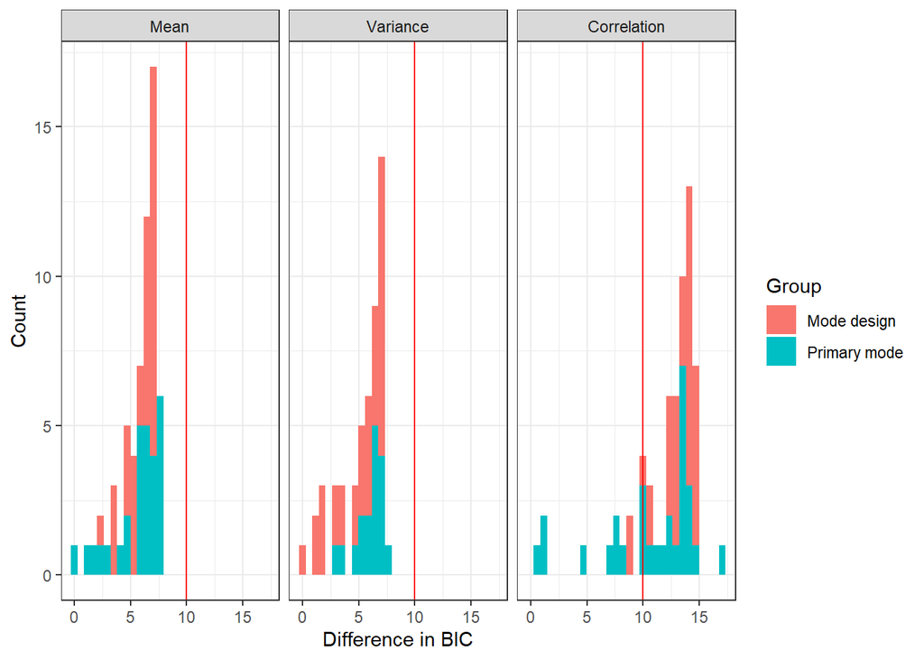

Significant mode design

| grp | model | sig_dif | n | prop |
| --- | --- | --- | --- | --- |
| Mode | cor | 0 | 13 | 0.0666667 |
| Mode | cor | 1 | 19 | 0.0974359 |
| Mode | mean | 0 | 32 | 0.1641026 |
| Mode | var | 0 | 32 | 0.1641026 |
| Mode design | cor | 0 | 3 | 0.0153846 |
| Mode design | cor | 1 | 30 | 0.1538462 |
| Mode design | mean | 0 | 33 | 0.1692308 |
| Mode design | var | 0 | 33 | 0.1692308 |

|  | FALSE | TRUE |
| --- | --- | --- |
| Binary (11) | 0.55 | 0.45 |
| Ordinal/continious (30) | 0.17 | 0.83 |

```
##
##  Pearson's Chi-squared test with Yates' continuity correction
##
## data:  vars_desc$type and vars_desc$sig_mm
## X-squared = 4.1114, df = 1, p-value = 0.0426
```

Non-significant mode difference

|  | FALSE | TRUE |
| --- | --- | --- |
| Binary (11) | 0.36 | 0.64 |
| Ordinal/continious (30) | 0.60 | 0.40 |

```
##
##  Pearson's Chi-squared test with Yates' continuity correction
##
## data:  vars_desc$type and vars_desc$sig_mode
## X-squared = 0.98272, df = 1, p-value = 0.3215
```

|  | FALSE | TRUE |
| --- | --- | --- |
| Health (26) | 0.15 | 0.85 |
| Other (15) | 0.47 | 0.53 |

```
##
##  Pearson's Chi-squared test with Yates' continuity correction
##
## data:  vars_desc$topic2 and vars_desc$sig_mm
## X-squared = 3.282, df = 1, p-value = 0.07004
```

Non-significant mode difference

|  | FALSE | TRUE |
| --- | --- | --- |
| Health (26) | 0.54 | 0.46 |
| Other (15) | 0.53 | 0.47 |

```
##
##  Pearson's Chi-squared test with Yates' continuity correction
##
## data:  vars_desc$topic2 and vars_desc$sig_mode
## X-squared = 0, df = 1, p-value = 1
```

### Show coefficients that are significantly different

Average differences

| Comparison | Coeffcient | Group | Mean difference |
| --- | --- | --- | --- |
| Mode | Correlation | Face to face | -0.39 |
| Mode | Correlation | Web | -0.24 |
| Mode | Variance intercept | Face to face | 9.50 |
| Mode | Variance intercept | Web | 9.81 |
| Mode design | Correlation | Mixed mode | -0.25 |
| Mode design | Correlation | Single mode | -0.23 |
| Mode design | Variance intercept | Mixed mode | 6.66 |
| Mode design | Variance intercept | Single mode | 6.49 |

Large differences can be found for:

| Comparison | Variable | Coeffcient | Group | Estimate |
| --- | --- | --- | --- | --- |
| Mode | jbterm1 | Correlation | Face to face | -0.48 |
| Mode | jbterm1 | Correlation | Web | -0.31 |
| Mode | jbterm1 | Variance intercept | Face to face | 28.63 |
| Mode | jbterm1 | Variance intercept | Web | 18.20 |
| Mode | mobuse | Correlation | Face to face | -0.23 |
| Mode | mobuse | Correlation | Web | 0.06 |
| Mode | mobuse | Variance intercept | Face to face | 32.13 |
| Mode | mobuse | Variance intercept | Web | 42.85 |
| Mode design | jbhas | Correlation | Mixed mode | -0.60 |
| Mode design | jbhas | Correlation | Single mode | -0.59 |
| Mode design | jbhas | Variance intercept | Mixed mode | 66.53 |
| Mode design | jbhas | Variance intercept | Single mode | 51.96 |
| Mode design | jbterm1 | Correlation | Mixed mode | -0.05 |
| Mode design | jbterm1 | Correlation | Single mode | -0.38 |
| Mode design | jbterm1 | Variance intercept | Mixed mode | 9.71 |
| Mode design | jbterm1 | Variance intercept | Single mode | 15.68 |

This is the distribution for the rest of the variables that are significantly different.

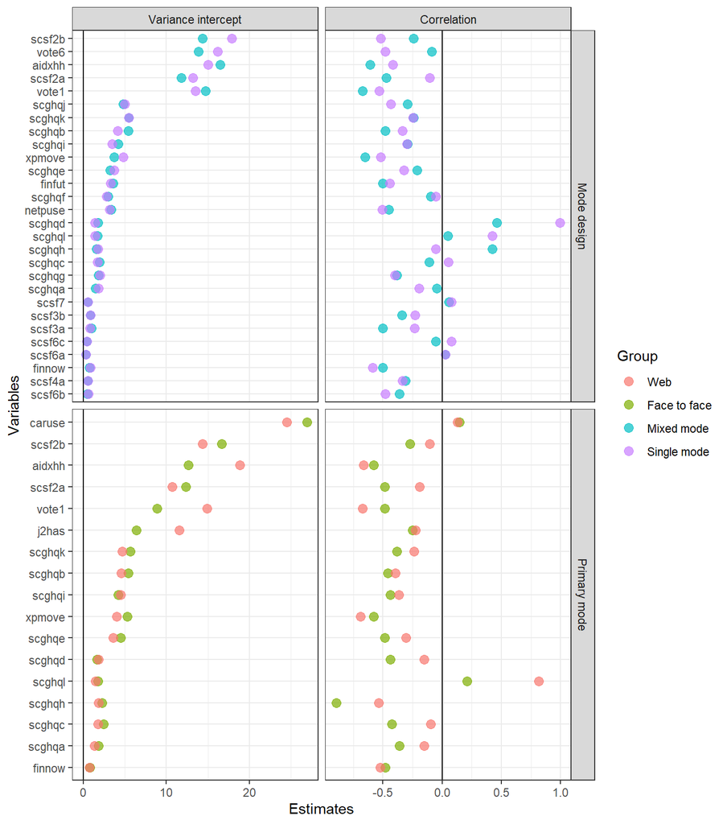

# Descriptives statistics?

### Descriptives for variables used in weighting